# Lab 1: Intro to data

Key

## Exercises:

#### Exercise 1:

There are 20,000 cases and 9 variables in this data set. `genhlth` is ordinal categorical; `exerany`, `hlthplan`, and `smoke100` are categorical; `height`, `weight`, `wtdesire`, and `age` are continuous, though they’ve been measured discretely; `gender` is categorical.

#### Exercise 2:

```r
cdc %>%
  group_by(exerany) %>%
  summarize(median_wt = median(weight))
```

```
## Source: local data frame [2 x 2]
##
##   exerany median_wt
##     (lgl)     (dbl)
## 1   FALSE       165
## 2    TRUE       165
```

The median weight of subjects who exercised in the last month and those who did not were the same: 165 lb.

#### Exercise 3:

```r
cdc %>%
  select(gender) %>%
  table()
```

```
## .
##     m     f
##  9569 10431
```

```r
cdc %>%
  select(gender) %>%
  table()/20000
```

```
## .
##       m       f
## 0.47845 0.52155
```

```r
cdc %>%
  select(genhlth) %>%
  table()/20000
```

```
## .
## excellent very good      good      fair      poor
##   0.23285   0.34860   0.28375   0.10095   0.03385
```

There are 9569 males in the sample. 23.3% of the sample reports being in excellent health. This exercise was poorly worded, so you may have also looked at the joint distribution of these two variables, which is fine.

#### Exercise 4:

```r
cdc %>%
  select(gender, smoke100) %>%
  table()
```

```
##       smoke100
## gender FALSE TRUE
##      m  4547 5022
##      f  6012 4419
```

#### Exercise 5:

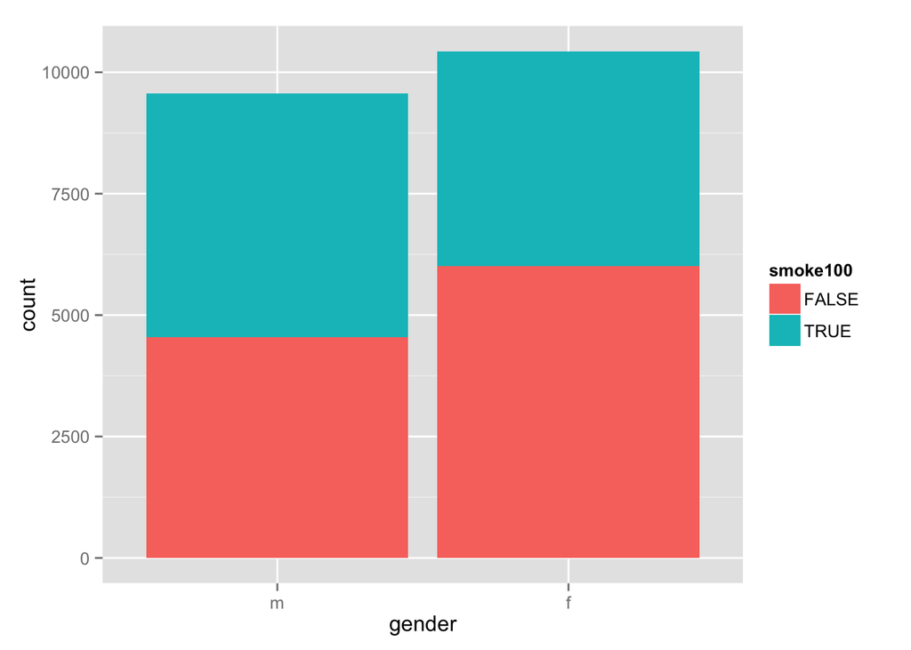

```r
qplot(x = gender, fill = smoke100, data = cdc)
```

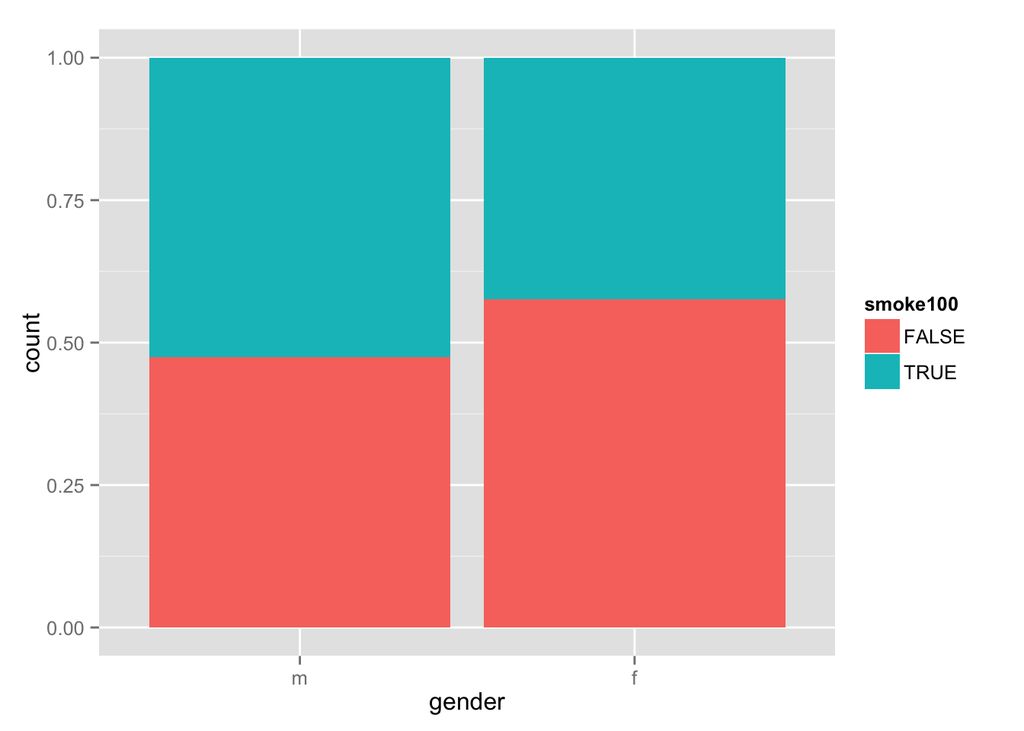

```r
qplot(x = gender, fill = smoke100, data = cdc, position = "fill")
```

The first plot shows only the counts of smokers/non-smokers in each gender while the second plot controls for the number of males and females and shows the proportion of smokers/non-smokers in each group. Similar to the reasoning in exercise 4, this second plot gives better insight into the relative proportion of smokers in the two groups.

#### Exercise 6:

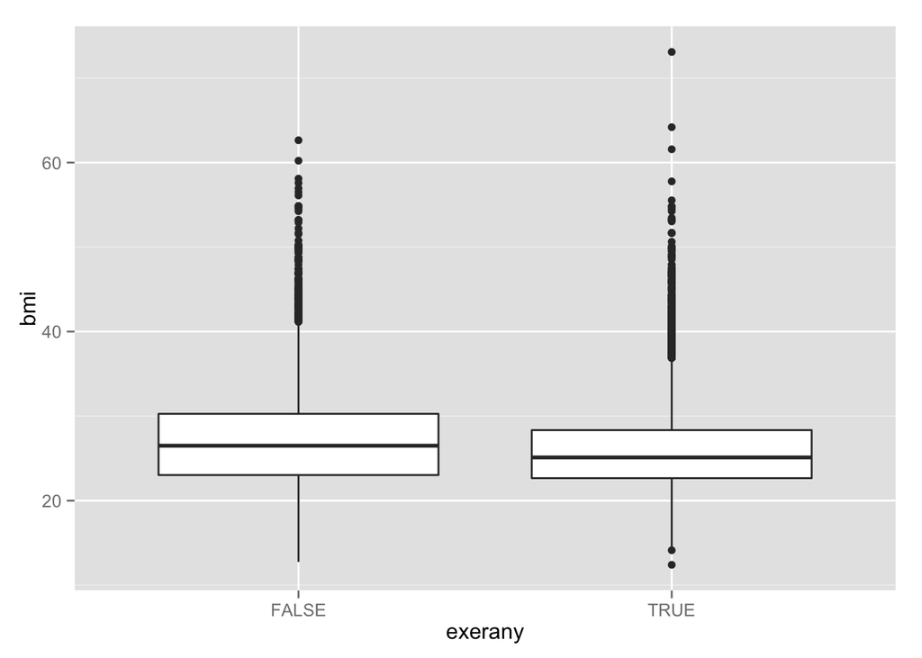

```r
cdc <- cdc %>%
  mutate(bmi = (weight / height^2) * 703)

qplot(y = bmi, x = exerany, data = cdc, geom = "boxplot")
```

Body mass index is likely effected by the level of physical activity so I chose to compare `bmi` to the `exerany` variable. The distribution of BMI in both groups is right skewed with many outliers. The exercisers had a lower median and Q3 BMI as well as a slightly lower Q1 BMI. This agrees with the intuition that those that exercise more will have a lower BMI, on average. There is a notable outlier, though: the highest BMI belongs to an exerciser.

#### Exercise 7:

```r
under23_and_smoke <- cdc %>%
  filter(smoke100 == TRUE & age < 23)
dim(under23_and_smoke)
```

```
## [1] 620  10
```

There are 620 subjects that fit the criteria of being smokers and under the age of 23.

## On your own:

#### 1:

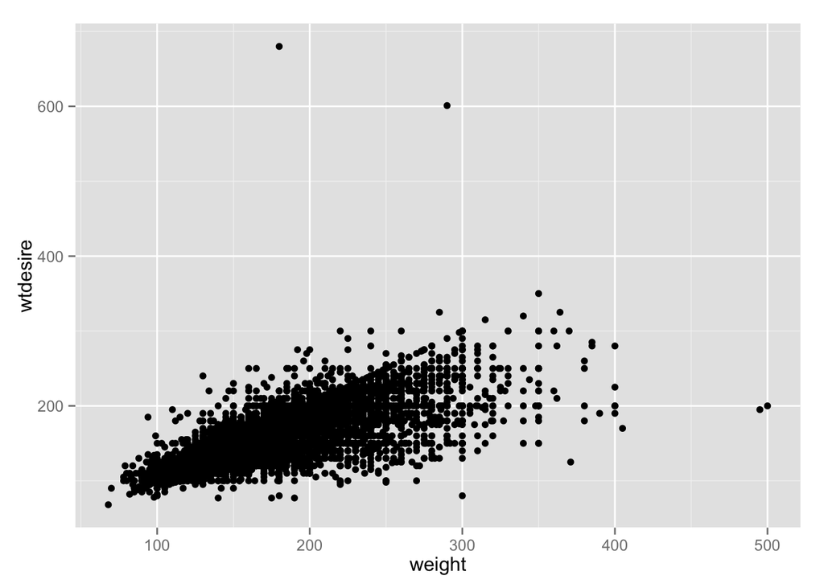

```r
qplot(x = weight, y = wtdesire, data = cdc, geom = "point")
```

There is a positive and roughly linear association between subjects’ weight and their desired weight. Notably, most of the points fall below the identity line, suggesting most people desire a weight that is lower than their recorded weight.

#### 2:

```r
cdc <- cdc %>%
  mutate(wdiff = wtdesire - weight)
```

#### 3:

`wdiff` is a continuous variable that has been measured discretely. A positive `wdiff` means that person wishes to gain weight; a negative `wdiff` means that person wishes to lose weight; and a `wdiff` of zero indicates that person is happy with their current weight.

#### 4:

```
## stat_bin: binwidth defaulted to range/30. Use 'binwidth = x' to adjust this.
```

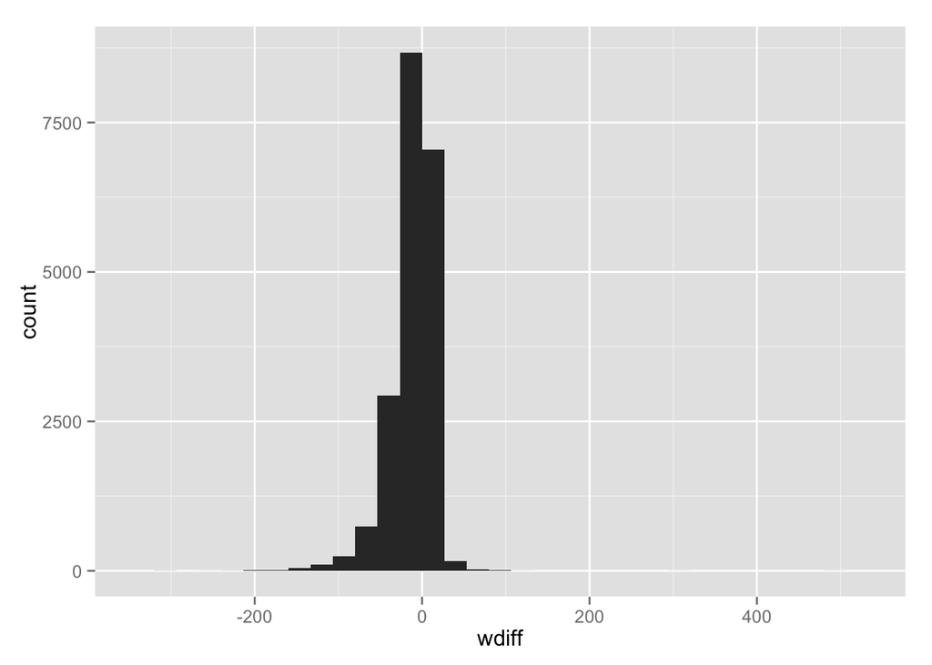

```r
qplot(x = wdiff, data = cdc, geom = "histogram")
```

```r
summary(cdc$wdiff)
```

```
##    Min. 1st Qu.  Median    Mean 3rd Qu.    Max.
## -300.00  -21.00  -10.00  -14.59    0.00  500.00
```

The `wdiff` data is centered at a median of -10 lb, meaning that the majority of people wish to lose weight. The IQR is 21 lb, though there is a low outlier at -300 lb and a high outlier at 500 lb. Excluding the outliers, the data appears to have a slight left skew.

#### 5:

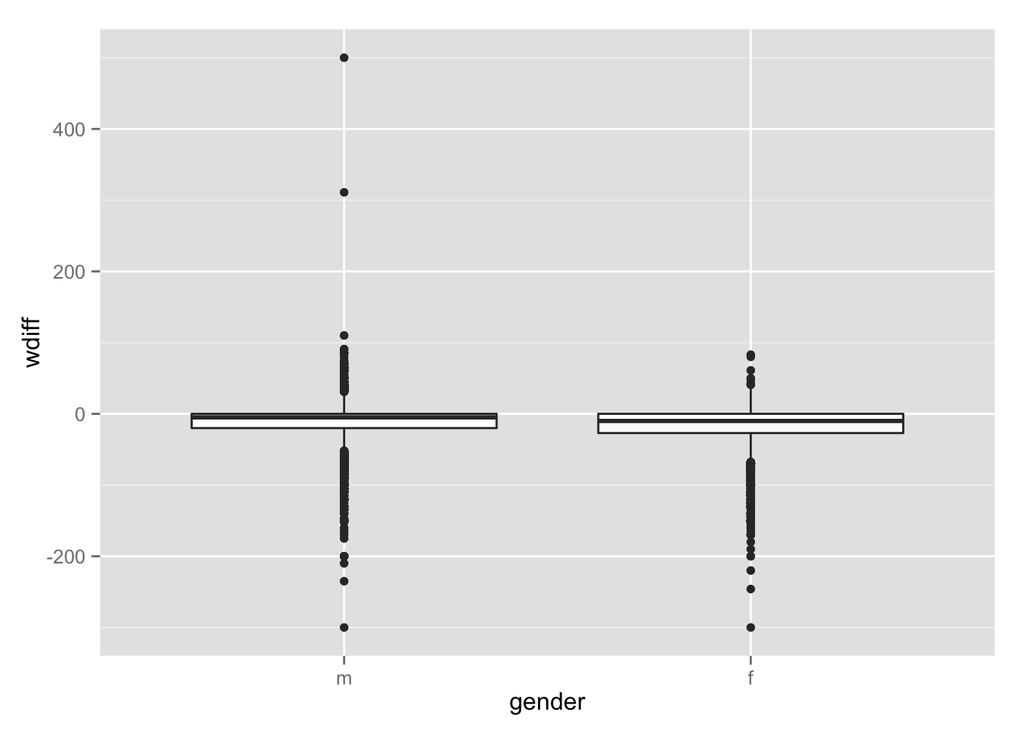

```r
qplot(x = gender, y = wdiff, data = cdc, geom = "boxplot")
```

The outliers dominate the range of the plot, so it’s difficult to compare the two groups. Looking closely, women have a lower Q1 and median `wdiff` than do men, suggesting more women wish to lose more weight than men.

Note: these plots can be improve by restricting the limits of the y-axis using the following additional argument.

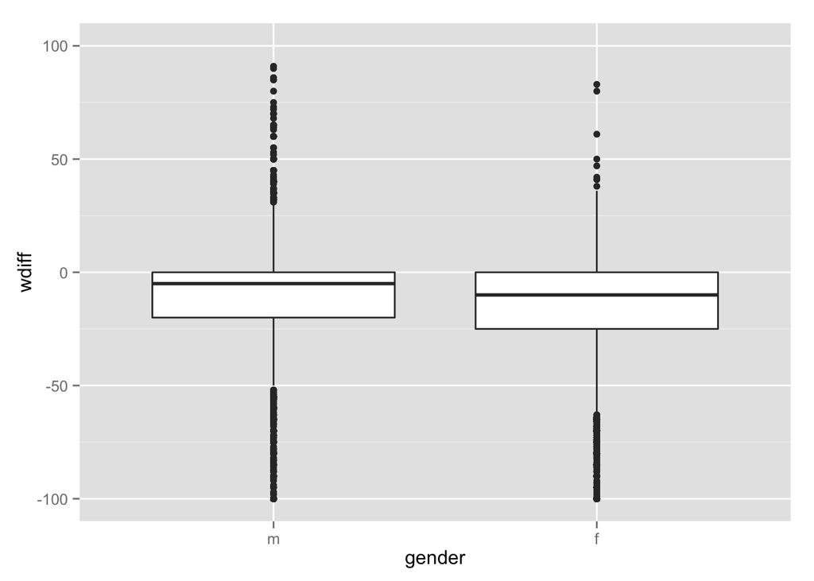

```r
qplot(x = gender, y = wdiff, data = cdc, geom = "boxplot", ylim = c(-100, 100))
```

#### 6:

```r
within_one_sd <- cdc %>%
  select(weight) %>%
  filter(weight < (mean(weight) + sd(weight)) &
           weight > (mean(weight) - sd(weight)))
dim(within_one_sd)
```

```
## [1] 14152     1
```

FYI: you can create a single pipeline to create that proportion using something we haven’t seen yet - the `ifelse` function.

```r
cdc %>%
  mutate(within_one_sd = ifelse(weight < (mean(weight) + sd(weight)) &
                                  weight > (mean(weight) - sd(weight)),
                                "yes", "no")) %>%
  group_by(within_one_sd) %>%
  summarize(n = n()) %>%
  mutate(prop = n / sum(n))
```

```
## Source: local data frame [2 x 3]
##
##   within_one_sd     n   prop
##           (chr) (int)  (dbl)
## 1            no  5848 0.2924
## 2           yes 14152 0.7076
```